# Exercise 5: Nonparametric IRT in R

```r
pm<-check.pmatrix(WIRS)
summary(pm) #6 significant violations for item 1, 3 for 5, 2 for Item 3, 1 for 4.
```

```
##        ItemH #ac #vi #vi/#ac maxvi  sum sum/#ac zmax #zsig crit
## Item 1 -0.06  20   6    0.30  0.09 0.33  0.0165 5.69     6  164
## Item 2  0.02  20   0    0.00  0.00 0.00  0.0000 0.00     0    0
## Item 3  0.25  20   2    0.10  0.04 0.08  0.0041 3.93     2   69
## Item 4  0.19  20   1    0.05  0.04 0.04  0.0019 2.23     1   45
## Item 5  0.26  20   3    0.15  0.09 0.21  0.0105 5.69     3  103
## Item 6  0.28  20   0    0.00  0.00 0.00  0.0000 0.00     0    0
```

4. Assess whether the assumption of monotonicity for the items holds (`check.monotonicity()`) and whether a Stochastic Ordering of the Latent Trait (Monontone Homogenity Model) holds (with the scalability coefficients `coefH()`).

```r
mon<-check.monotonicity(WIRS)
summary(mon) #5 significant violations for item 1.
```

```
##        ItemH #ac #vi #vi/#ac maxvi  sum sum/#ac zmax #zsig crit
## Item 1 -0.06  10   7     0.7  0.29 1.04  0.1041 5.06     5  331
## Item 2  0.02   6   0     0.0  0.00 0.00  0.0000 0.00     0    0
## Item 3  0.25   6   0     0.0  0.00 0.00  0.0000 0.00     0    0
## Item 4  0.19   6   0     0.0  0.00 0.00  0.0000 0.00     0    0
## Item 5  0.26   6   0     0.0  0.00 0.00  0.0000 0.00     0    0
## Item 6  0.28  10   0     0.0  0.00 0.00  0.0000 0.00     0    0
```

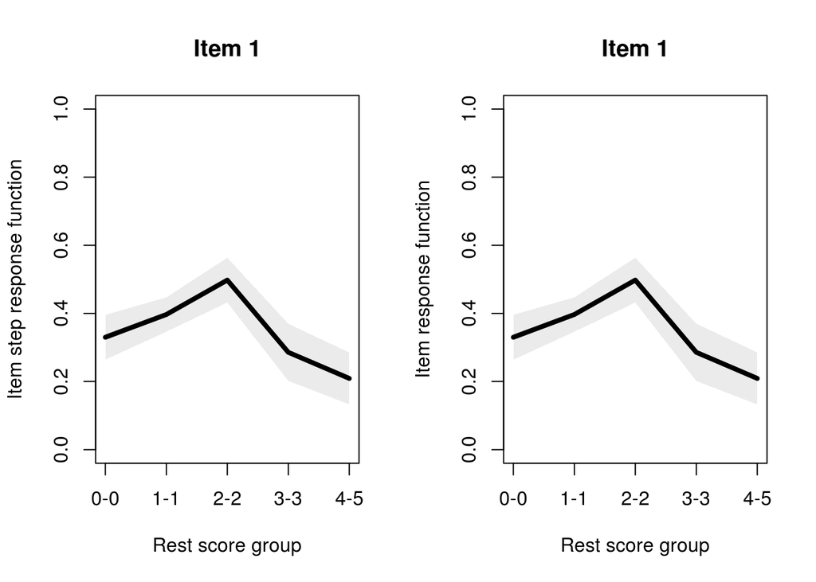

```r
plot(mon,1) #No
```

```r
sol<-coefH(WIRS)
sol #negative H_ij, negative H_i and H is very low. We can't rank order persons here. Culprit is item 1.
```

```
## $Hij
##        Item 1   se      Item 2   se      Item 3  se      Item 4   se
## Item 1                   -0.490  (0.052)  0.090  (0.039)  -0.139  (0.042)
## Item 2  -0.490  (0.052)                   0.122  (0.059)   0.393  (0.061)
## Item 3   0.090  (0.039)   0.122  (0.059)                   0.260  (0.039)
## Item 4  -0.139  (0.042)   0.393  (0.061)  0.260  (0.039)
## Item 5   0.089  (0.033)   0.178  (0.049)  0.414  (0.039)   0.290  (0.044)
## Item 6   0.159  (0.060)   0.157  (0.087)  0.360  (0.053)   0.218  (0.049)
##        Item 5  se      Item 6  se
## Item 1  0.089  (0.033)  0.159  (0.060)
## Item 2  0.178  (0.049)  0.157  (0.087)
## Item 3  0.414  (0.039)  0.360  (0.053)
## Item 4  0.290  (0.044)  0.218  (0.049)
## Item 5                  0.474  (0.057)
## Item 6  0.474  (0.057)
##
## $Hi
##        Item H  se
## Item 1  -0.058 (0.023)
## Item 2   0.023 (0.033)
## Item 3   0.249 (0.020)
## Item 4   0.192 (0.023)
## Item 5   0.263 (0.018)
## Item 6   0.283 (0.028)
##
## $H
##  Scale H se
##    0.154 (0.015)
```

5. In 4) we may have found a reason for the scaling problems. Investigate this further with smoothing models. First, fit a smoothing spline model with `mirt()`. Investigate the model with the IRF plot. What do you find out about Item 1? Also check fit, total score plot and distribution of the latent trait. Is this satisfactory? What do you say about the IRF of Items 2, 4, 5?

```r
splinem<-mirt(WIRS,1,itemtype="spline", verbose=FALSE)
```

```
## EM cycles terminated after 500 iterations.
```

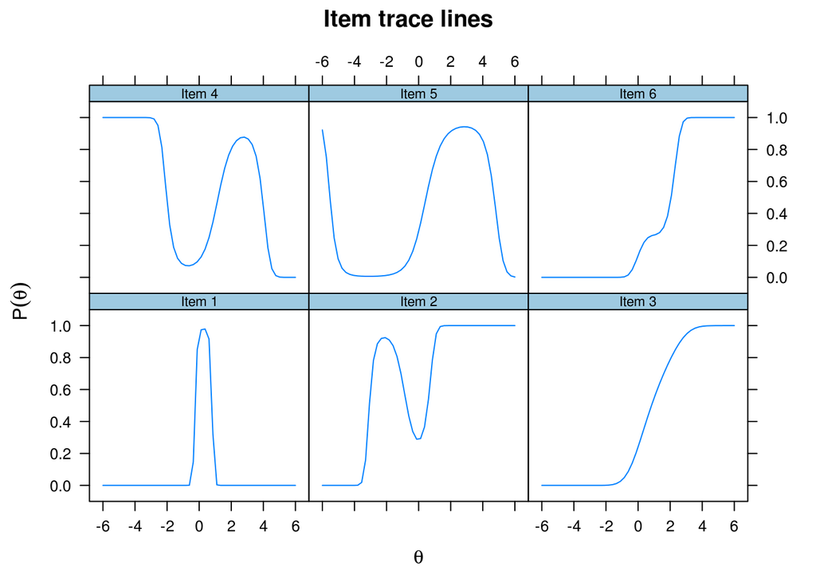

```r
plot(splinem,type="trace")  #
```